# Loan Purchasing Prediction

## Libraries

```python
import pandas as pd
import matplotlib.pyplot as plt
import seaborn as sns
from yellowbrick.model_selection import FeatureImportances
#Confusion matrix and classification report
from sklearn import metrics
from sklearn.metrics import classification_report, confusion_matrix,accuracy_score,f1_score
from sklearn.tree import DecisionTreeRegressor
from sklearn.tree import DecisionTreeClassifier
from sklearn.linear_model import LogisticRegression
from sklearn.model_selection import train_test_split
import warnings
warnings.filterwarnings('ignore')
```

- Pandas is used for data manipulation like importing, cleaning data
- Matplotlib is used for data visualization
- Seaborn is another library that is used for data visualization making beautiful graphs than matplotlib
- The Yellowbrick library is a diagnostic visualization platform for machine learning that allows data scientists to steer the model selection process
- Metrics used for model's evaluation
- Import machine learning algorithms and other metrics from sklearn library
- Import warning to ignore any kind of warning in data visualization

# Exploratory data analysis

Exploratory data analysis is the method of examining data and extracting findings. It's fiction, a storyline that data is attempting to convey. EDA is a way of analyzing data using a variety of tools and graphical approaches such as matplotlib, charts, heatmap, scatterplots and seaborn.The first phase in the data modelling process is often EDA.

## Importing dataset

```python
#read_csv() function is used to import data with comma delimeted files
data = pd.read_csv("Loan_Modelling.csv")
data
```

|  | ID | Age | Experience | Income | ZIPCode | Family | CCAvg | Education | Mortgage | Personal_Loan | Securities_Account | CD_Account | Online | CreditCard |
| --- | --- | --- | --- | --- | --- | --- | --- | --- | --- | --- | --- | --- | --- | --- |
| 0 | 1 | 25 | 1 | 49 | 91107 | 4 | 1.6 | 1 | 0 | 0 | 1 | 0 | 0 | 0 |
| 1 | 2 | 45 | 19 | 34 | 90089 | 3 | 1.5 | 1 | 0 | 0 | 1 | 0 | 0 | 0 |
| 2 | 3 | 39 | 15 | 11 | 94720 | 1 | 1.0 | 1 | 0 | 0 | 0 | 0 | 0 | 0 |
| 3 | 4 | 35 | 9 | 100 | 94112 | 1 | 2.7 | 2 | 0 | 0 | 0 | 0 | 0 | 0 |
| 4 | 5 | 35 | 8 | 45 | 91330 | 4 | 1.0 | 2 | 0 | 0 | 0 | 0 | 0 | 1 |
| ... | ... | ... | ... | ... | ... | ... | ... | ... | ... | ... | ... | ... | ... | ... |
| 4995 | 4996 | 29 | 3 | 40 | 92697 | 1 | 1.9 | 3 | 0 | 0 | 0 | 0 | 1 | 0 |
| 4996 | 4997 | 30 | 4 | 15 | 92037 | 4 | 0.4 | 1 | 85 | 0 | 0 | 0 | 1 | 0 |
| 4997 | 4998 | 63 | 39 | 24 | 93023 | 2 | 0.3 | 3 | 0 | 0 | 0 | 0 | 0 | 0 |
| 4998 | 4999 | 65 | 40 | 49 | 90034 | 3 | 0.5 | 2 | 0 | 0 | 0 | 0 | 1 | 0 |
| 4999 | 5000 | 28 | 4 | 83 | 92612 | 3 | 0.8 | 1 | 0 | 0 | 0 | 0 | 1 | 1 |

5000 rows × 14 columns

```python
print("There are {} rows & {} columns in our dataset.".format(data.shape[0],data.shape[1]))
```

```
There are 5000 rows & 14 columns in our dataset.
```

```python
# describe function will provide some basic statistics of the dataset
data.describe()
```

|  | ID | Age | Experience | Income | ZIPCode | Family | CCAvg | Education | Mortgage | Personal_Loan | Securities_Account | CD_Account | Online | CreditCard |
| --- | --- | --- | --- | --- | --- | --- | --- | --- | --- | --- | --- | --- | --- | --- |
| count | 5000.000000 | 5000.000000 | 5000.000000 | 5000.000000 | 5000.000000 | 5000.000000 | 5000.000000 | 5000.000000 | 5000.000000 | 5000.000000 | 5000.000000 | 5000.00000 | 5000.000000 | 5000.000000 |
| mean | 2500.500000 | 45.338400 | 20.104600 | 73.774200 | 93169.257000 | 2.396400 | 1.937938 | 1.881000 | 56.498800 | 0.096000 | 0.104400 | 0.06040 | 0.596800 | 0.294000 |
| std | 1443.520003 | 11.463166 | 11.467954 | 46.033729 | 1759.455086 | 1.147663 | 1.747659 | 0.839869 | 101.713802 | 0.294621 | 0.305809 | 0.23825 | 0.490589 | 0.455637 |
| min | 1.000000 | 23.000000 | -3.000000 | 8.000000 | 90005.000000 | 1.000000 | 0.000000 | 1.000000 | 0.000000 | 0.000000 | 0.000000 | 0.00000 | 0.000000 | 0.000000 |
| 25% | 1250.750000 | 35.000000 | 10.000000 | 39.000000 | 91911.000000 | 1.000000 | 0.700000 | 1.000000 | 0.000000 | 0.000000 | 0.000000 | 0.00000 | 0.000000 | 0.000000 |
| 50% | 2500.500000 | 45.000000 | 20.000000 | 64.000000 | 93437.000000 | 2.000000 | 1.500000 | 2.000000 | 0.000000 | 0.000000 | 0.000000 | 0.00000 | 1.000000 | 0.000000 |
| 75% | 3750.250000 | 55.000000 | 30.000000 | 98.000000 | 94608.000000 | 3.000000 | 2.500000 | 3.000000 | 101.000000 | 0.000000 | 0.000000 | 0.00000 | 1.000000 | 1.000000 |
| max | 5000.000000 | 67.000000 | 43.000000 | 224.000000 | 96651.000000 | 4.000000 | 10.000000 | 3.000000 | 635.000000 | 1.000000 | 1.000000 | 1.00000 | 1.000000 | 1.000000 |

```python
# info provide the breif summary about the dataset
data.info()
```

```
<class 'pandas.core.frame.DataFrame'>
RangeIndex: 5000 entries, 0 to 4999
Data columns (total 14 columns):
 #   Column              Non-Null Count  Dtype
---  ------              --------------  -----
 0   ID                  5000 non-null   int64
 1   Age                 5000 non-null   int64
 2   Experience          5000 non-null   int64
 3   Income              5000 non-null   int64
 4   ZIPCode             5000 non-null   int64
 5   Family              5000 non-null   int64
 6   CCAvg               5000 non-null   float64
 7   Education           5000 non-null   int64
 8   Mortgage            5000 non-null   int64
 9   Personal_Loan       5000 non-null   int64
 10  Securities_Account  5000 non-null   int64
 11  CD_Account          5000 non-null   int64
 12  Online              5000 non-null   int64
 13  CreditCard          5000 non-null   int64
dtypes: float64(1), int64(13)
memory usage: 547.0 KB
```

```python
# dtypes provides data dtypes of our dataset columns
data.dtypes
```

```
ID                      int64
Age                     int64
Experience              int64
Income                  int64
ZIPCode                 int64
Family                  int64
CCAvg                 float64
Education               int64
Mortgage                int64
Personal_Loan           int64
Securities_Account      int64
CD_Account              int64
Online                  int64
CreditCard              int64
dtype: object
```

```python
data.skew(numeric_only=True)
```

```
ID                    0.000000
Age                  -0.029341
Experience           -0.026325
Income                0.841339
ZIPCode              -0.296165
Family                0.155221
CCAvg                 1.598443
Education             0.227093
Mortgage              2.104002
Personal_Loan         2.743607
Securities_Account    2.588268
CD_Account            3.691714
Online               -0.394785
CreditCard            0.904589
dtype: float64
```

## Univariate analysis

Uni stands for "one," meaning that there is just one sort of variable in the data. Univariate analysis' main purpose is to characterise the data. The information will be collected, analysed, and a pattern will be identified. Univariate analysis can be carried out in a number of methods, the most of which are descriptive. Frequency Polygons, Histograms, and Bar Charts are all examples of frequency distribution tables.

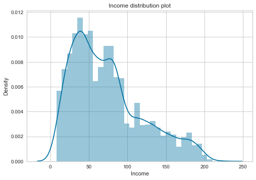

```python
#using seaborn library to plot distribution plot and dropping null values
sns.distplot(data['Income'].dropna());
plt.title("Income distribution plot")
```

> Most of the data found between 20 and 100 customers having higher ratio of Income is less than normal

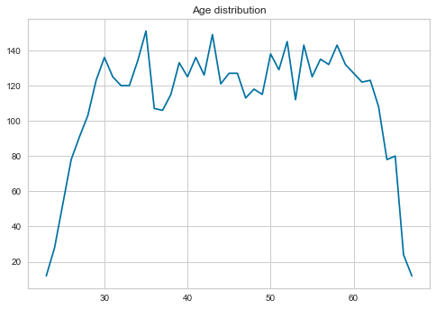

```python
#plotting age column data using count function and sorting index
data['Age'].value_counts().sort_index().plot.line()
plt.title("Age distribution")
```

> Higher spikes can be seen over the range 30 and 60.

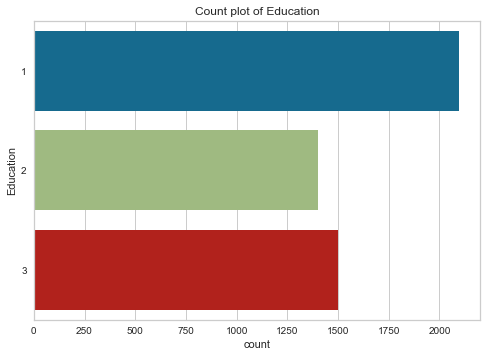

```python
#plotting countplot using seaborn to see different levels of education
sns.countplot(y = data['Education'])
plt.title("Count plot of Education")
plt.show()
```

> This graph is basically a countplot. Total number of values for a certain level. We can see customers having education level 1 is more than other levels

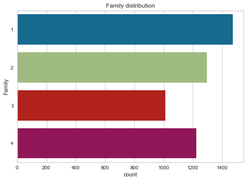

```python
# Count plot to see distrubtion of family with respect to total members
sns.countplot(y = data['Family'])
plt.title("Family distribution")
plt.show()
```

> Another countplot showing the family distribution. Family having 1 are more than other levels

## Bivariate Analysis

Bivariate Analysis means 2. Comparsion of two variables to illustarte some meaningful information is bivariate analysis.  
It can be heatmaps,scatterplots, histograms,line-plots

- Seaborn's lmplot is a 2D scatterplot with an optional overlaid regression line. This is useful for comparing numeric variables.
- Logistic regression for binary classification is also supported with lmplot

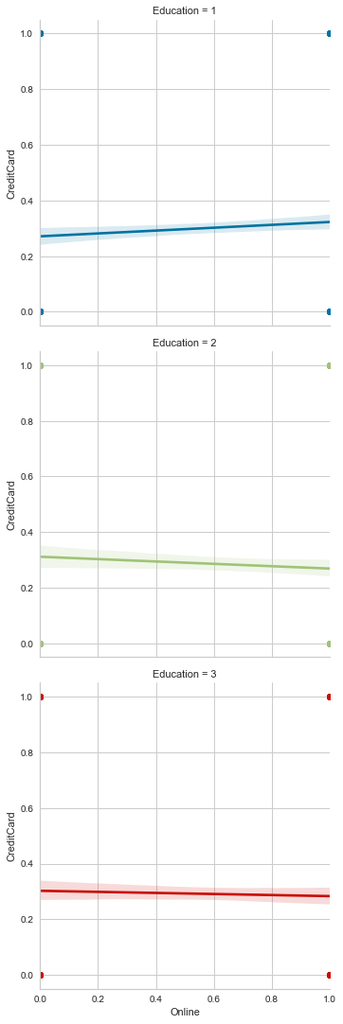

```python
#plotting lmplot with x as online and y on creditcard with education levels
sns.lmplot(data = data, x ='Online', y= 'CreditCard', hue = 'Education',row = 'Education' )
plt.show()
```

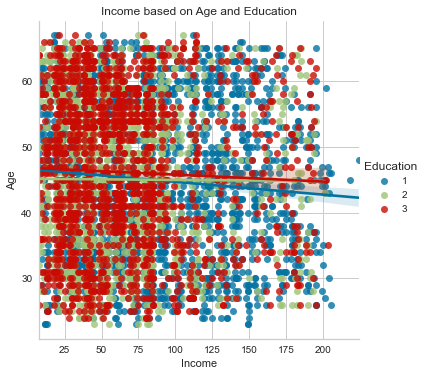

```python
sns.lmplot(data = data, x ='Income', y= 'Age', hue = 'Education' )
plt.title("Income based on Age and Education")
plt.figure(figsize = (8,6))
plt.show()
```

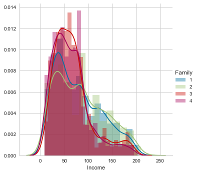

```python
#FacetGrid object takes a dataframe as input and the names of the variables that will form the row, column, or hue dimensions of the grid.
sns.FacetGrid(data,hue = "Family",size =5).map(sns.distplot,"Income").add_legend()
```

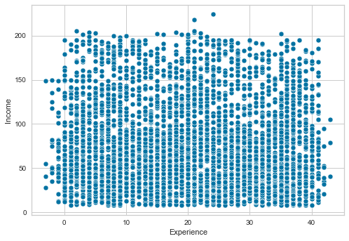

```python
sns.scatterplot(x =data['Experience'], y =data['Income'])
```

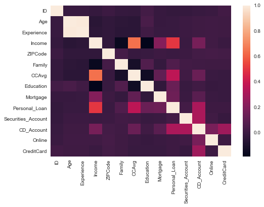

```python
#finding a correlation and plotting a heatmap to get better understanding of the data
corr=data.corr()
sns.heatmap(corr)
```

Inference from Bivariate Analysis:  
The number of customers with higher education are acquiring Personal Loan compared to other groups.  
Family with size more than 2 are more intrested in personal loans  
There is a higher correlation in Age and Experience feature so we can drop one of them.  
Correlation coefficient of ID and target variable Personal Loan is negative and close to zero so we can drop the variable.  
Correlation coefficient of Age and Experience are negative and close to zero so we can drop these variables as well.

## Illustrate the insights based on EDA

```python
age_cut = pd.cut(data['Age'],bins=[20,30,40,50,60])
pd.crosstab(age_cut,data['Personal_Loan']).apply(lambda r: r/r.sum()*100, axis=1)
```

| Personal_Loan Age | 0 | 1 |
| --- | --- | --- |
| (20, 30] | 89.423077 | 10.576923 |
| (30, 40] | 90.453074 | 9.546926 |
| (40, 50] | 90.393701 | 9.606299 |
| (50, 60] | 91.307634 | 8.692366 |

From above table as well as distribution plot of Age attribute, one can observe that most of the customers lie in the age group of 30 to 60. Also,one can observe that 10.5% of the total customers in age group 20-30 have acquired personal loan from the bank, while in age groups (30-40), (40-50) and (50-60), there is a conversion rate of around 9%.

```python
exp_cut = pd.cut(data['Experience'],bins=[0,10,20,30,40,50])
pd.crosstab(exp_cut,data['Personal_Loan']).apply(lambda r: r/r.sum()*100, axis=1)
```

| Personal_Loan Experience | 0 | 1 |
| --- | --- | --- |
| (0, 10] | 89.239966 | 10.760034 |
| (10, 20] | 90.582602 | 9.417398 |
| (20, 30] | 90.853190 | 9.146810 |
| (30, 40] | 90.661831 | 9.338169 |
| (40, 50] | 87.037037 | 12.962963 |

```python
inc_cut = pd.cut(data['Income'],bins=[0,50,100,150,200,250])
pd.crosstab(inc_cut,data['Personal_Loan']).apply(lambda r: r/r.sum()*100, axis=1)
```

| Personal_Loan Income | 0 | 1 |
| --- | --- | --- |
| (0, 50] | 100.000000 | 0.000000 |
| (50, 100] | 97.758805 | 2.241195 |
| (100, 150] | 71.428571 | 28.571429 |
| (150, 200] | 49.530516 | 50.469484 |
| (200, 250] | 81.250000 | 18.750000 |

No customer with income < 50,000$ opted for the personal loan where as half of the cutomers with income within the range of 150 to 200 thousand dollars acquired personal loan...! Customers within range of (100 to 150) and (200 to 250) thousand dollars showed a conversion rate of about 28.5% and 18.75%, respectively.

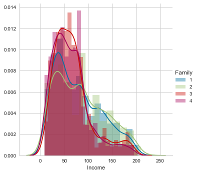

```python
sns.FacetGrid(data,hue = "Family",size =5).map(sns.distplot,"Income").add_legend()
```

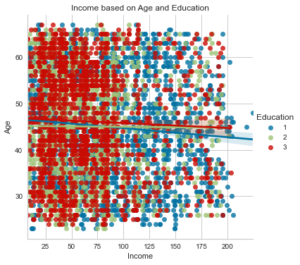

```python
sns.lmplot(data = data, x ='Income', y= 'Age', hue = 'Education' )
plt.title("Income based on Age and Education")
plt.figure(figsize = (8,6))
plt.show()
```

> This illustration is of Income that is based on Age and education levels. From the output it is clearly shown that Customers having more education levels are having income between 25 and 100.We can see a huge dense distrubtion of red colors on the left side of plot from top to bottom.

|  | ID | Age | Experience | Income | ZIPCode | Family | CCAvg | Education | Mortgage | Personal_Loan | Securities_Account | CD_Account | Online | CreditCard |
| --- | --- | --- | --- | --- | --- | --- | --- | --- | --- | --- | --- | --- | --- | --- |
| ID | 1.000000 | -0.008473 | -0.008326 | -0.017695 | 0.002240 | -0.016797 | -0.024675 | 0.021463 | -0.013920 | -0.024801 | -0.016972 | -0.006909 | -0.002528 | 0.017028 |
| Age | -0.008473 | 1.000000 | 0.994215 | -0.055269 | -0.030530 | -0.046418 | -0.052012 | 0.041334 | -0.012539 | -0.007726 | -0.000436 | 0.008043 | 0.013702 | 0.007681 |
| Experience | -0.008326 | 0.994215 | 1.000000 | -0.046574 | -0.030456 | -0.052563 | -0.050077 | 0.013152 | -0.010582 | -0.007413 | -0.001232 | 0.010353 | 0.013898 | 0.008967 |
| Income | -0.017695 | -0.055269 | -0.046574 | 1.000000 | -0.030709 | -0.157501 | 0.645984 | -0.187524 | 0.206806 | 0.502462 | -0.002616 | 0.169738 | 0.014206 | -0.002385 |
| ZIPCode | 0.002240 | -0.030530 | -0.030456 | -0.030709 | 1.000000 | 0.027512 | -0.012188 | -0.008266 | 0.003614 | -0.002974 | 0.002422 | 0.021671 | 0.028317 | 0.024033 |
| Family | -0.016797 | -0.046418 | -0.052563 | -0.157501 | 0.027512 | 1.000000 | -0.109275 | 0.064929 | -0.020445 | 0.061367 | 0.019994 | 0.014110 | 0.010354 | 0.011588 |
| CCAvg | -0.024675 | -0.052012 | -0.050077 | 0.645984 | -0.012188 | -0.109275 | 1.000000 | -0.136124 | 0.109905 | 0.366889 | 0.015086 | 0.136534 | -0.003611 | -0.006689 |
| Education | 0.021463 | 0.041334 | 0.013152 | -0.187524 | -0.008266 | 0.064929 | -0.136124 | 1.000000 | -0.033327 | 0.136722 | -0.010812 | 0.013934 | -0.015004 | -0.011014 |
| Mortgage | -0.013920 | -0.012539 | -0.010582 | 0.206806 | 0.003614 | -0.020445 | 0.109905 | -0.033327 | 1.000000 | 0.142095 | -0.005411 | 0.089311 | -0.005995 | -0.007231 |
| Personal_Loan | -0.024801 | -0.007726 | -0.007413 | 0.502462 | -0.002974 | 0.061367 | 0.366889 | 0.136722 | 0.142095 | 1.000000 | 0.021954 | 0.316355 | 0.006278 | 0.002802 |
| Securities_Account | -0.016972 | -0.000436 | -0.001232 | -0.002616 | 0.002422 | 0.019994 | 0.015086 | -0.010812 | -0.005411 | 0.021954 | 1.000000 | 0.317034 | 0.012627 | -0.015028 |
| CD_Account | -0.006909 | 0.008043 | 0.010353 | 0.169738 | 0.021671 | 0.014110 | 0.136534 | 0.013934 | 0.089311 | 0.316355 | 0.317034 | 1.000000 | 0.175880 | 0.278644 |
| Online | -0.002528 | 0.013702 | 0.013898 | 0.014206 | 0.028317 | 0.010354 | -0.003611 | -0.015004 | -0.005995 | 0.006278 | 0.012627 | 0.175880 | 1.000000 | 0.004210 |
| CreditCard | 0.017028 | 0.007681 | 0.008967 | -0.002385 | 0.024033 | 0.011588 | -0.006689 | -0.011014 | -0.007231 | 0.002802 | -0.015028 | 0.278644 | 0.004210 | 1.000000 |

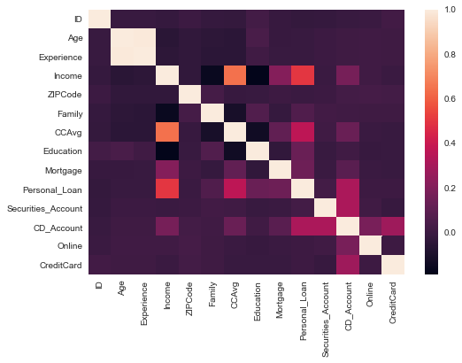

```python
#finding a correlation and plotting a heatmap to get better understanding of the data
corr=data.corr()
sns.heatmap(corr)
corr
```

> From the heatmap we can find some correlation between Income and education features of the dataset.Also income and CCAvg

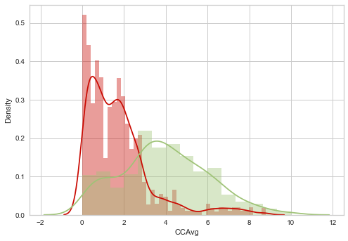

```python
sns.distplot( data[data.Personal_Loan == 0]['CCAvg'], color = 'r')
sns.distplot( data[data.Personal_Loan == 1]['CCAvg'], color = 'g')
```

```python
print('Credit card spending of Non-Loan customers: ',data[data.Personal_Loan == 0]['CCAvg'].median()*1000)
print('Credit card spending of Loan customers    : ', data[data.Personal_Loan == 1]['CCAvg'].median()*1000)
```

```
Credit card spending of Non-Loan customers:  1400.0
Credit card spending of Loan customers    :  3800.0
```

The graph show persons who have personal loan have a higher credit card average. Average credit card spending with a median of 3800 dollar indicates a higher probability of personal loan. Lower credit card spending with a median of 1400 dollars is less likely to take a loan. This could be useful information.

## Data Pre-processing

### Checking for null values

```python
data.isnull().sum()
```

```
ID                    0
Age                   0
Experience            0
Income                0
ZIPCode               0
Family                0
CCAvg                 0
Education             0
Mortgage              0
Personal_Loan         0
Securities_Account    0
CD_Account            0
Online                0
CreditCard            0
dtype: int64
```

> We have found that there are no null values inside the dataset. So our data is clean and ready to go for further implementations

```python
data.duplicated().sum()
```

```
0
```

> So no duplication is found inside the dataset we are ready to go

### Data Splitting and feature Engineering

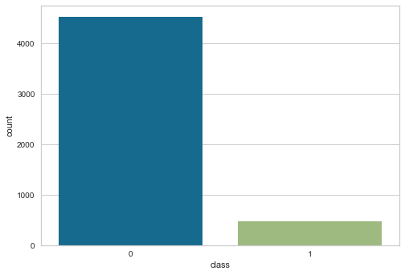

```python
# Since target attribute is binary in nature, let us see count for each class
data['Personal_Loan'].value_counts()
#Converting above target class distribution as dataframe
df_target = data['Personal_Loan'].value_counts()
df_target = pd.DataFrame({'class':df_target.index, 'count':df_target.values})
# barplot for target column distribution
sns.barplot(x='class',y = 'count',data=df_target)
```

```python
# Let us add the percentage column to the dataframe.
data['Percentage'] = df_target['count']/df_target['count'].sum()*100
df_target
```

|  | class | count |
| --- | --- | --- |
| 0 | 0 | 4520 |
| 1 | 1 | 480 |

We are taking the personal loan as our traget variable so for this purpose we are splitting the data into X and y by droping Personal loan column in X

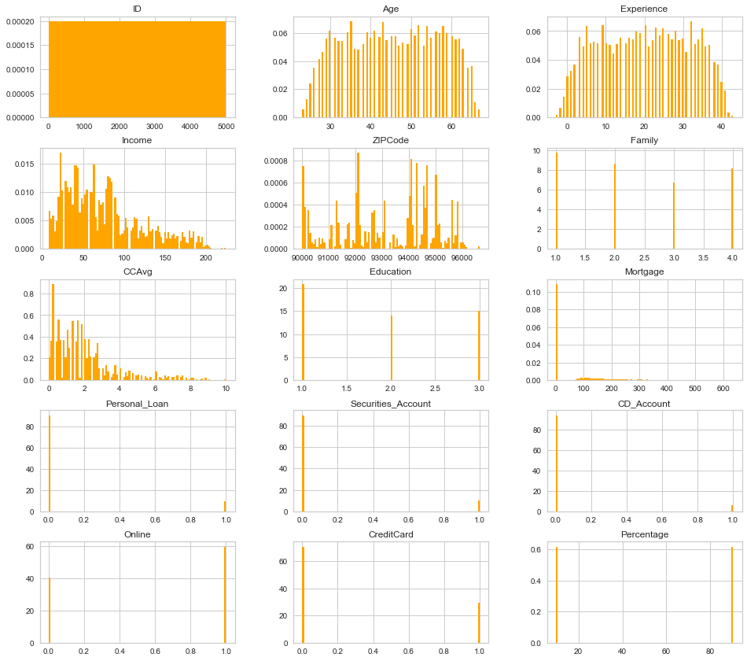

```python
columns=list(data)
data[columns].hist(stacked=True,density=True, bins=100,color='Orange', figsize=(16,30), layout=(10,3));
```

```python
#taking all columns except personal loan
data =data.drop('Percentage',1)
X = data.drop('Personal_Loan',1)
#target variable
y = data.Personal_Loan
```

```python
print(X.shape)
print(y.shape)
```

```
(5000, 13)
(5000,)
```

> By printing the shape of X and y we have found (5000,13) entries in X and only (5000) in y that is good so far.

```python
#splitting the data into train and test
X_train, X_test, y_train, y_test = train_test_split(X, y, test_size=0.2, random_state=2)
```

```python
#finding the shapes of the train and test set
print(X_train.shape)
print(y_train.shape)
print(X_test.shape)
print(y_test.shape)
```

```
(4000, 13)
(4000,)
(1000, 13)
(1000,)
```

# Logistic Regression

```python
#importing the model
lr = LogisticRegression()
# fitting on x and y training set data
lr.fit(X_train, y_train)
```

```
LogisticRegression()
```

```python
#Prediction of test set
y_pred = lr.predict(X_test)
#Predicted values
y_pred
```

[output not shown]

[output cut: 31 more lines]

```python
import statsmodels.api as sm
logit_model=sm.Logit(y,X)
result=logit_model.fit()
print(result.summary())
```

```
Optimization terminated successfully.
         Current function value: 0.129110
         Iterations 9
                           Logit Regression Results
==============================================================================
Dep. Variable:          Personal_Loan   No. Observations:                 5000
Model:                          Logit   Df Residuals:                     4987
Method:                           MLE   Df Model:                           12
Date:                Sat, 10 Jul 2021   Pseudo R-squ.:                  0.5917
Time:                        19:36:13   Log-Likelihood:                -645.55
converged:                       True   LL-Null:                       -1581.0
Covariance Type:            nonrobust   LLR p-value:                     0.000
======================================================================================
                         coef    std err          z      P>|z|      [0.025      0.975]
--------------------------------------------------------------------------------------
ID                 -5.636e-05   5.13e-05     -1.099      0.272      -0.000    4.41e-05
Age                   -0.1167      0.059     -1.981      0.048      -0.232      -0.001
Experience             0.1248      0.059      2.125      0.034       0.010       0.240
Income                 0.0541      0.003     20.791      0.000       0.049       0.059
ZIPCode               -0.0001   1.67e-05     -6.628      0.000      -0.000   -7.81e-05
Family                 0.6859      0.074      9.284      0.000       0.541       0.831
CCAvg                  0.1221      0.040      3.087      0.002       0.045       0.200
Education              1.7335      0.114     15.162      0.000       1.509       1.958
Mortgage               0.0005      0.001      0.814      0.416      -0.001       0.002
Securities_Account    -0.9659      0.285     -3.388      0.001      -1.525      -0.407
CD_Account             3.8544      0.323     11.919      0.000       3.221       4.488
Online                -0.6761      0.157     -4.312      0.000      -0.983      -0.369
CreditCard            -1.1185      0.204     -5.483      0.000      -1.518      -0.719
======================================================================================
```

### Finding the most important features

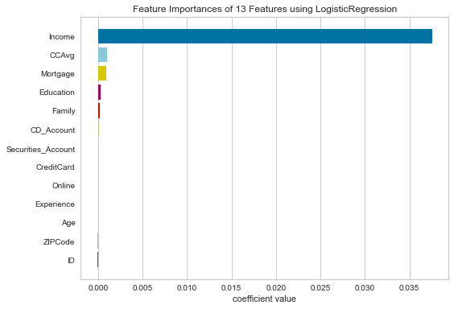

```python
#using features importance function and fitting on X and y to find important features
viz = FeatureImportances(lr, relative=False)
viz.fit(X, y)
viz.show()
```

> According to our output,it can be seen that income is the most important feature of our dataset with respect to our dependent variable  
> We can say that Income is highly dependent on the customer to acquire a personal loan or not

### Model Evaluation

```python
#Actual value and the predicted value
a = pd.DataFrame({'Actual value': y_test, 'Predicted value':y_pred})
a.head()
```

|  | Actual value | Predicted value |
| --- | --- | --- |
| 3566 | 0 | 0 |
| 4252 | 0 | 0 |
| 1918 | 1 | 0 |
| 4111 | 0 | 0 |
| 1471 | 0 | 1 |

Printing the confusion matrix and plotting a heat map

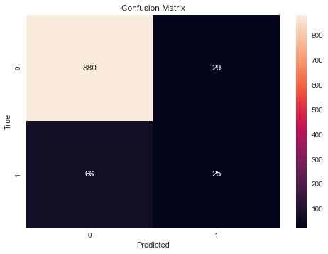

```python
# confusion matrix with respect to test and predicted data
matrix = confusion_matrix(y_test, y_pred)
#plotting a heat map for better visualization
sns.heatmap(matrix, annot=True, fmt="d")
plt.title('Confusion Matrix')
plt.xlabel('Predicted')
plt.ylabel('True')
# printing the classification report
#print(classification_report(y_test, y_pred))
```

In data science, model evaluation is critical. It assists you in comprehending your model's performance and makes it simple to exhibit your model to others. There are numerous evaluation metrics available, but only a few of them are adequate for regression.  
The metrics that are best and we are using are :

- Mean square error
- Root Mean square error
- Accuracy Score

#### Mean Squared Error

```python
##computing mean squared error
from sklearn.metrics import mean_squared_error
print(mean_squared_error(y_test, y_pred))
```

```
0.095
```

> From the results it is clear that our MSE is not much high

#### Root Mean Squared Error

```python
# computing root mean squared error
from sklearn.metrics import mean_squared_error
import math
print(math.sqrt(mean_squared_error(y_test, y_pred)))
```

```
0.3082207001484488
```

#### Accuracy Score

```python
#getting the score for our model
score = lr.score(X_test, y_test)
print(score)
```

```
0.905
```

> So our accuracy is 90% and it's good for any model. It can be increased by adding some more data to our model

### Classification Reports

```python
cm=confusion_matrix(y_test,y_pred,labels=[0,1])
print(cm)
score=accuracy_score(y_test,y_pred)
f1_score=f1_score(y_test,y_pred)
print("Accuracy Score  for Logistic Regression:{}".format(score*100))
print("F1 Score  for Logistic Regression :{}".format(f1_score*100))
print(classification_report(y_test,y_pred))
```

```
[[880  29]
 [ 66  25]]
Accuracy Score  for Logistic Regression:90.5
F1 Score  for Logistic Regression :34.48275862068966
              precision    recall  f1-score   support

           0       0.93      0.97      0.95       909
           1       0.46      0.27      0.34        91

    accuracy                           0.91      1000
   macro avg       0.70      0.62      0.65      1000
weighted avg       0.89      0.91      0.89      1000
```

## Improvement of logistic regression

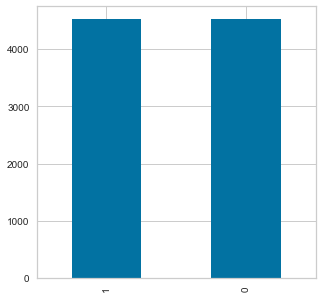

```python
#resampling the target variable
from  sklearn.utils import resample
df_majority=data[data['Personal_Loan']==0]
df_minority=data[data['Personal_Loan']==1]
df_upsample_minority=resample(df_minority,replace=True,random_state=12,n_samples=4520)
df_upsample=pd.concat([df_majority,df_upsample_minority])
count=df_upsample['Personal_Loan'].value_counts()
count.plot(kind='bar',figsize=(5,5));
```

Now imbalanced has been changed.Both classes for our dependent variable are same and have less unsampled data which we can ignore. Now we are going to apply logistic regression again to sampled and unsampled data to see the variations of the data and results

```python
X_upsampled=df_upsample.drop(['Personal_Loan'],axis=1)
Y_upsampled=df_upsample['Personal_Loan']
```

```python
X_upsampled_test,X_upsampled_train,Y_upsampled_test,Y_upsampled_train=train_test_split(X_upsampled,Y_upsampled,random_state=1,test_size=0.3)
lr.fit(X_upsampled_train,Y_upsampled_train)
Pred_Upsample_Log=lr.predict(X_upsampled_test)
cm_model1_upsample=confusion_matrix(Y_upsampled_test,Pred_Upsample_Log,labels=[0,1])
cm_model1_upsample
```

```
array([[2686,  472],
       [ 385, 2785]], dtype=int64)
```

```python
print(classification_report(Y_upsampled_test,Pred_Upsample_Log))
```

```
              precision    recall  f1-score   support

           0       0.87      0.85      0.86      3158
           1       0.86      0.88      0.87      3170

    accuracy                           0.86      6328
   macro avg       0.86      0.86      0.86      6328
weighted avg       0.86      0.86      0.86      6328
```

As you can see our model produces an accuracy of 86% which is good and we have increased the precision and recall upto 86 and 88% respectively

## ROC and AUC Score & ODDS

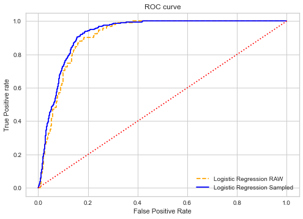

```python
from sklearn.metrics import roc_curve,auc,roc_auc_score

#Perform Predictions for all models both with raw data and upsampled data

PRED_PROB_LOG_RAW=lr.predict_proba(X_test)
PRED_PROB_LOG_SAMPLED=lr.predict_proba(X_upsampled_test)
#calculate fpr,tpr,threshold
fpr1, tpr1, thresh1 = roc_curve(y_test, PRED_PROB_LOG_RAW[:,1], pos_label=1)
fpr2,tpr2,thresh2= roc_curve(Y_upsampled_test,PRED_PROB_LOG_SAMPLED[:,1],pos_label=1)
random_probs = [0 for i in range(len(y_test))]
p_fpr, p_tpr, _ = roc_curve(y_test, random_probs, pos_label=1)
AUC_LOG_RAW=roc_auc_score(y_test,PRED_PROB_LOG_RAW[:,1])
AUC_LOG_SAMPLED=roc_auc_score(Y_upsampled_test,PRED_PROB_LOG_SAMPLED[:,1])
#Plot Area Under Curve

plt.plot(fpr1,tpr1,linestyle='--',color='orange', label='Logistic Regression RAW')
plt.plot(fpr2,tpr2,linestyle='solid',color='blue', label='Logistic Regression Sampled')
plt.plot(p_fpr, p_tpr, linestyle=':', color='red')
# title
plt.title('ROC curve')
# x label
plt.xlabel('False Positive Rate')
# y label
plt.ylabel('True Positive rate')

plt.legend(loc='best')
```

```python
print("ROC_AUC_Score for Logistic Regression with Raw Data:{}".format(AUC_LOG_RAW))
print("ROC_AUC_Score for Logistic Regression after improved  Data:{}".format(AUC_LOG_SAMPLED))
```

```
ROC_AUC_Score for Logistic Regression with Raw Data:0.9101052962439101
ROC_AUC_Score for Logistic Regression after improved  Data:0.9234038833826465
```

So we are having a score for roc for the previous data and model 91% and for the improve done we have 92%

# Decision Tree

```python
#building the model
regressor = DecisionTreeRegressor()
regressor.fit(X_train, y_train)
```

```
DecisionTreeRegressor()
```

```python
#making predictions about the test data
y_pred1 = regressor.predict(X_test)
```

```python
#printing actual vs predicted values
df=pd.DataFrame({'Actual':y_test, 'Predicted':y_pred})
df.head(5)
```

|  | Actual | Predicted |
| --- | --- | --- |
| 3566 | 0 | 0 |
| 4252 | 0 | 0 |
| 1918 | 1 | 0 |
| 4111 | 0 | 0 |
| 1471 | 0 | 1 |

```python
from sklearn.metrics import confusion_matrix
print(confusion_matrix(y_test, y_pred1))
```

```
[[904   5]
 [ 13  78]]
```

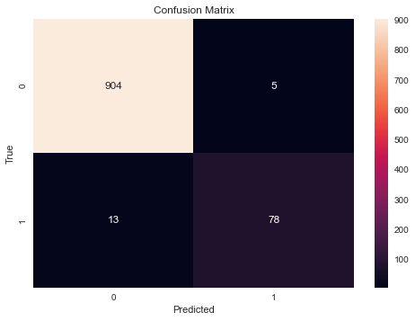

```python
# confusion matrix with respect to test and predicted data
matrix = confusion_matrix(y_test, y_pred1)
#plotting a heat map for better visualization
sns.heatmap(matrix, annot=True, fmt="d")
plt.title('Confusion Matrix')
plt.xlabel('Predicted')
plt.ylabel('True')
# printing the classification report
#print(classification_report(y_test, y_pred))
```

```python
prun = regressor.cost_complexity_pruning_path(X_train,y_train)
alphas=prun['ccp_alphas']
alphas
```

```
array([0.00000000e+00, 8.14393939e-05, 1.07142857e-04, 1.13636364e-04,
       1.16666667e-04, 1.23563218e-04, 1.42857143e-04, 1.66666667e-04,
       1.74825175e-04, 1.87500000e-04, 1.87500000e-04, 2.14285714e-04,
       2.22222222e-04, 2.28070175e-04, 2.28260870e-04, 2.35524892e-04,
       2.37500000e-04, 2.50000000e-04, 2.56410256e-04, 2.76315789e-04,
       2.78571429e-04, 3.05297499e-04, 4.00142150e-04, 4.25556713e-04,
       4.34027778e-04, 4.49388613e-04, 5.00595238e-04, 1.18635580e-03,
       1.61164906e-03, 2.47464173e-03, 1.20705882e-02, 2.84700090e-02])
```

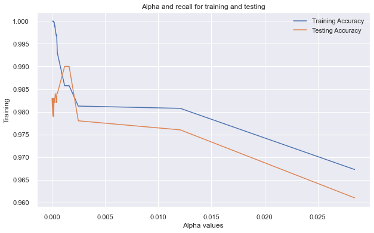

```python
##on the whole data
train_accuracy, test_accuracy=[],[]

for j in alphas:
    tree= DecisionTreeClassifier(ccp_alpha=j)
    tree.fit(X_train,y_train)
    ytrain_pred=tree.predict(X_train)
    ytest_pred=tree.predict(X_test)
    train_accuracy.append(accuracy_score(y_train, ytrain_pred))
    test_accuracy.append(accuracy_score(y_test, ytest_pred))

sns.set()
plt.figure(figsize=(10,6))
sns.lineplot(y=train_accuracy, x=alphas, label='Training Accuracy')
sns.lineplot(y=test_accuracy, x=alphas, label='Testing Accuracy')
plt.xlabel("Alpha values")
plt.ylabel("Training")
plt.title("Alpha and recall for training and testing")
plt.show()
```

### Model's Evaluation

```python
from sklearn.metrics import classification_report
print(classification_report(y_test,y_pred1))
```

```
              precision    recall  f1-score   support

           0       0.99      0.99      0.99       909
           1       0.94      0.86      0.90        91

    accuracy                           0.98      1000
   macro avg       0.96      0.93      0.94      1000
weighted avg       0.98      0.98      0.98      1000
```

## Hyper tuning

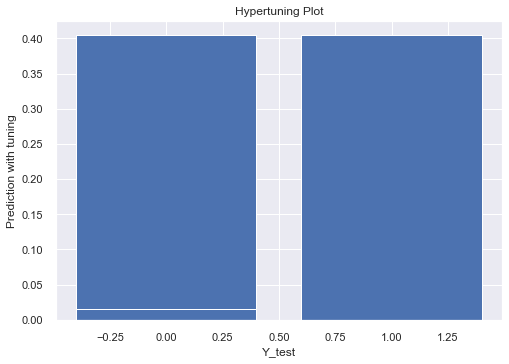

```python
tuned_hyper_model= DecisionTreeRegressor(max_depth=5,max_features='auto',
                                         max_leaf_nodes=50,min_samples_leaf=2,
                                         min_weight_fraction_leaf=0.1,splitter='random')
tuned_hyper_model.fit(X_train,y_train)
#making predictions
tuned_pred=tuned_hyper_model.predict(X_test)
#plotting
plt.bar(y_test,tuned_pred)
plt.title("Hypertuning Plot")
plt.xlabel("Y_test")
plt.ylabel("Prediction with tuning")
plt.show()
```

```python
print('MAE:', metrics.mean_absolute_error(y_test,tuned_pred))
print('MSE:', metrics.mean_squared_error(y_test, tuned_pred))
```

```
MAE: 0.12381998848008456
MSE: 0.06192274460972627
```

### Finding the most Important Features

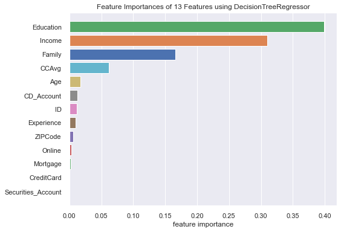

```python
viz = FeatureImportances(regressor, relative=False)
viz.fit(X, y)
viz.show()
```

> So from our this model's output we have seen education is kept as most important feature and income is on second and family on third.  
> We can say person having more education will likely to acuire personal loan or rejects it

> The accuracy of the model is 98% which is high and good for any model's statistics

### Actionable Insights & Recommendations

From the results of our two models  
1) Accuracy for logistic regression was 90%  
2) Accuracy for Descision tree was 98%  
Most Important feature:

- Logistic Regression : Income
- Decision Tree : Education  
  Based on our results we can predict that people having education will likely to borrow personal loan as they will know about the consequences.  
  We will go with the model that having more accuracy on predicting test data

### Perform an Exploratory Data Analysis on the incorrectly predicted data

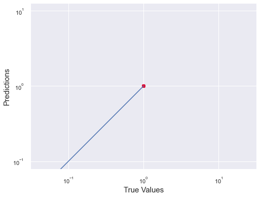

```python
plt.figure(figsize=(8,6))
plt.scatter(y_test, y_pred, c='crimson')
plt.yscale('log')
plt.xscale('log')

p1 = max(max(y_pred), max(y_test))
p2 = min(min(y_pred), min(y_test))
plt.plot([p1, p2], [p1, p2], 'b-')
plt.xlabel('True Values', fontsize=15)
plt.ylabel('Predictions', fontsize=15)
plt.axis('equal')
plt.show()
```

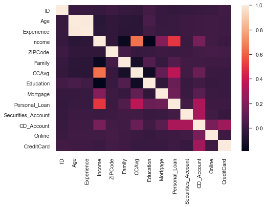

```python
X_test.corr()
sns.heatmap(corr)
```

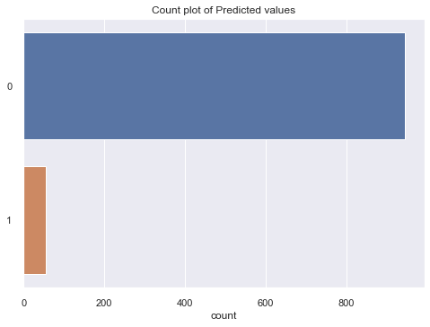

```python
#plotting countplot using seaborn to saw different levels of education
sns.countplot(y = y_pred)
plt.title("Count plot of Predicted values")
plt.show()
```

```python
#printing actual vs predicted values
df=pd.DataFrame({'Actual':y_test, 'Predicted':y_pred})
df.head(5)
```

|  | Actual | Predicted |
| --- | --- | --- |
| 3566 | 0 | 0 |
| 4252 | 0 | 0 |
| 1918 | 1 | 0 |
| 4111 | 0 | 0 |
| 1471 | 0 | 1 |

## Conclusions

We got the dataset about personal loan which includes customers important features highlighting income, Age, Education. We perform EDA on our dataset and find few important patterns from it. After evaluating two different ML algoirthms we can predict that:

- Customers having education will buy personal loan
- Customers that have higher income will buy personal loan  
  Management should focus on education as well as income of the customers to extract results about personal loan borrow

## Recommendations

The bank instead of calling someone for purchasing a loan should focus on the key features like Education of the customer, Income of the customer, total family members, and CCAVG of the customer.  
It seems that customers who have higher education level and with above average income have the higher proportion to purchase the personal loan.  
Clients with these characteristics should be targeted in the Business Plan to increase their access to Personal Loans.  
The bank can expand its reach outside its existing customer base. Consumers who match the criteria in its service area and beyond detected as a result of our predictive modelling.